# R dyntrace report

K. Siek, A. Goel

## Dataset

```
 [1] "BMS"           "car"           "caschrono"     "catdata"
 [5] "cellranger"    "checkmate"     "colorspace"    "copula"
 [9] "curl"          "data"          "DBI"           "digest"
[13] "dplyr"         "foreach"       "forecast"      "Formula"
[17] "gamclass"      "gdata"         "ggplot2"       "grid"
[21] "gridExtra"     "highr"         "htmlwidgets"   "iterators"
[25] "jsonlite"      "knitr"         "lazyeval"      "lme4"
[29] "lmtest"        "lubridate"     "magrittr"      "markdown"
[33] "mvtnorm"       "nloptr"        "pbkrtest"      "proto"
[37] "psych"         "purrr"         "quantreg"      "R6"
[41] "Rcpp"          "RcppArmadillo" "RcppEigen"     "readr"
[45] "readxl"        "rivr"          "rlang"         "rprojroot"
[49] "RSQLite"       "Sleuth3"       "sp"            "SparseM"
[53] "stringr"       "tibble"        "tidyr"         "vcd"
[57] "viridis"       "xml2"          "xtable"        "xts"
[61] "zoo"
```

## Overview

| package | functions | calls | promises | promise accesses | promise forces | promise lookups |
| --- | --- | --- | --- | --- | --- | --- |
| * | 57.8k | 148mln | 115.2mln | 133mln | 84.2mln | 48.9mln |
| psych | 3.0k | 11mln | 4.9mln | 10mln | 4.4mln | 5.5mln |
| vcd | 1.4k | 13mln | 9.2mln | 13mln | 6.9mln | 6.0mln |
| copula | 1.7k | 22mln | 25.3mln | 20mln | 15.5mln | 4.3mln |
| BMS | 1.1k | 29mln | 17.4mln | 24mln | 11.6mln | 12.6mln |
| pbkrtest | 1.7k | 32mln | 26.5mln | 27mln | 19.8mln | 7.1mln |

**promise force** means the promise is accessed and the code of the promise is executed  
**promise lookup** mean the promise is accessed and the code of the promise is not executed

## Promise accesses

[output not shown]

**promise force** means the promise is accessed and the code of the promise is executed  
**promise lookup** mean the promise is accessed and the code of the promise is not executed

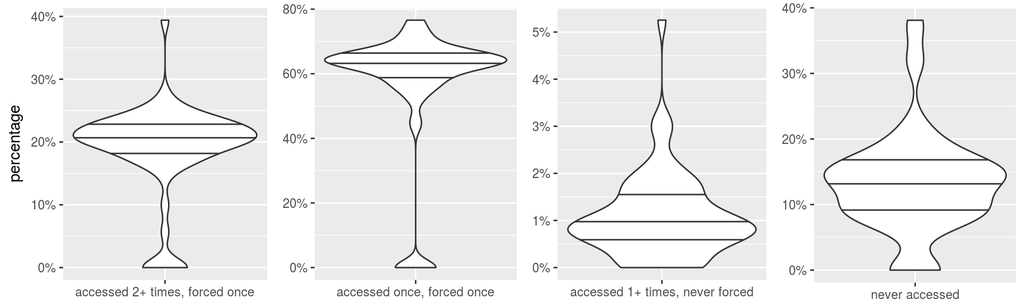

## Number of accesses to a promise

### Aggregate

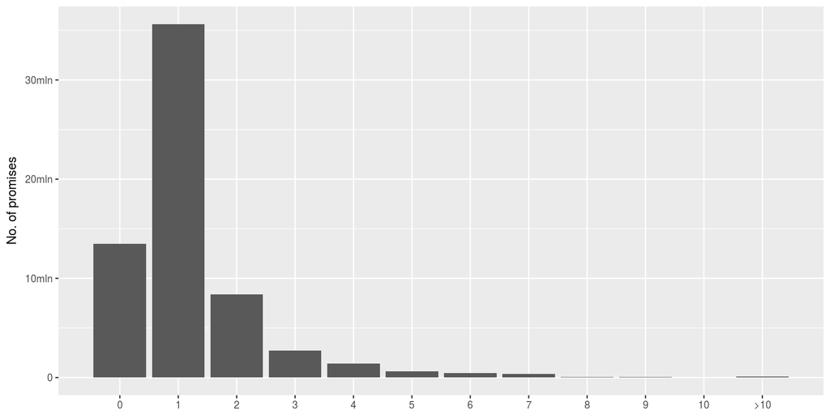

### Distribution per package

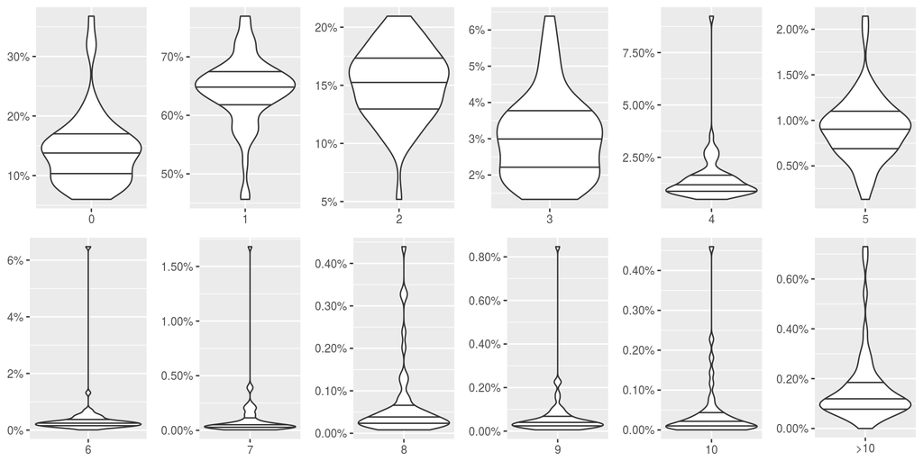

### Separate results per package

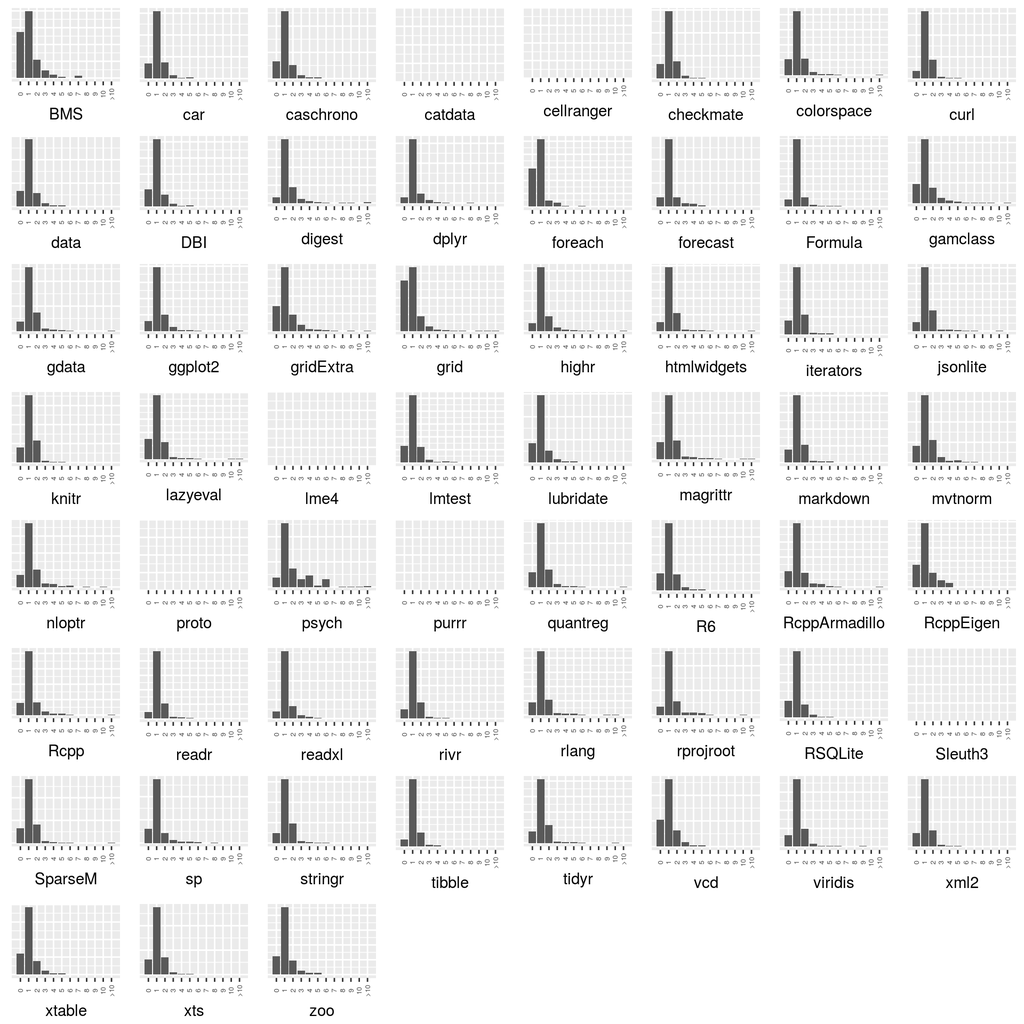

## Promise code types

### Aggregate

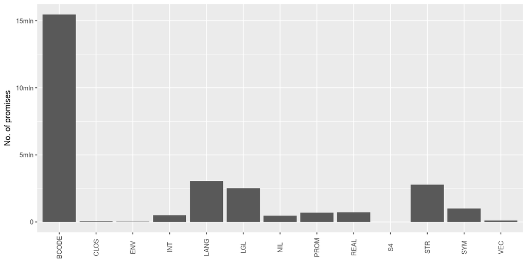

Promise types follow the type designations in `Rinternals.h`.

### Distribution per package

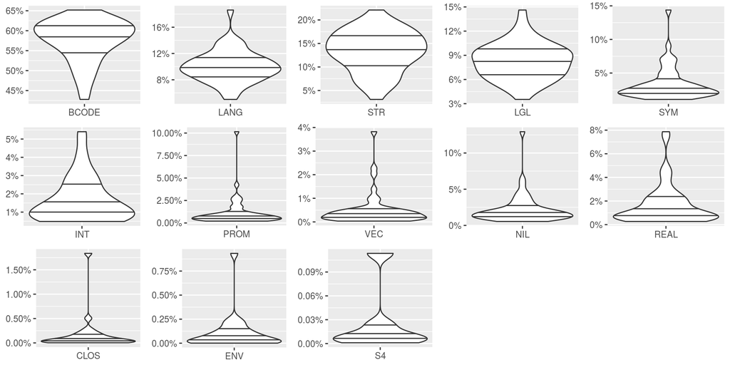

### Separate results per package

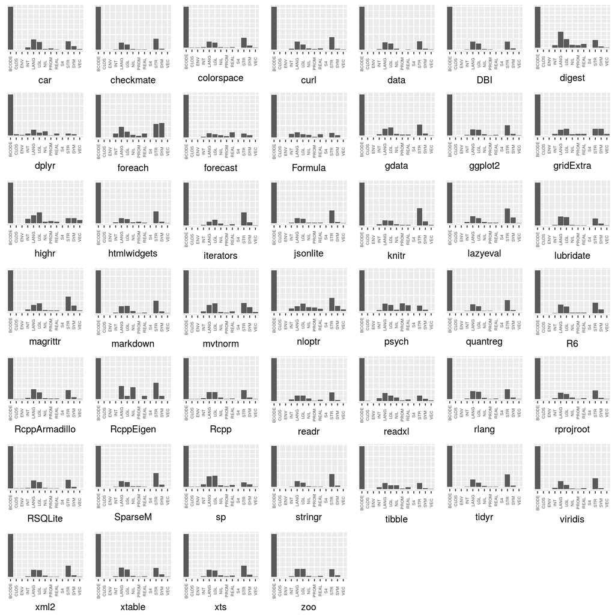

## What’s inside promises?

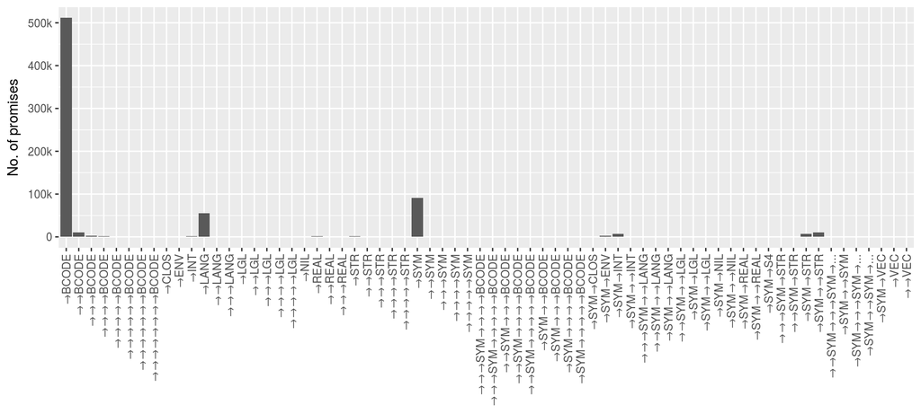

Promise types follow the type designations in `Rinternals.h`.  
**α** indicates that the promise contains the expression of type **α**.  
**→α** indicates that the promise contains a promise which contains the expression of type **α**, etc.

## What do promises return?

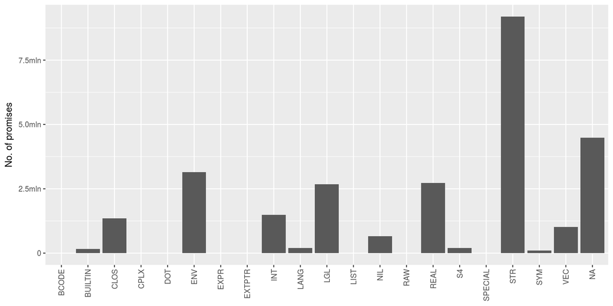

Promise types follow the type designations in `Rinternals.h`.

## What do specific promises return?

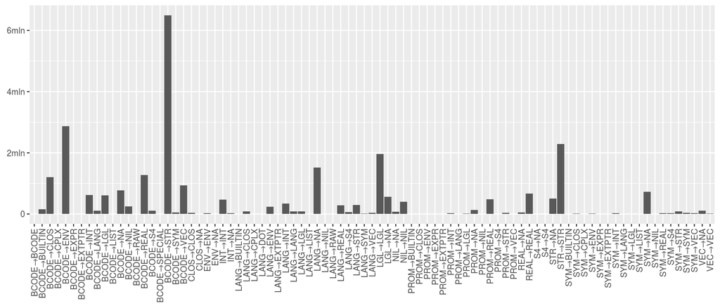

Promise types follow the type designations in `Rinternals.h`.  
**α→β** indicates that the promise contains an expression of type **α** which evaluates to an expression of type **β** when the promise is forced.

## Promise forces by types

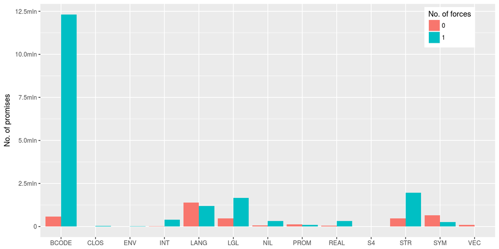

Promise types follow the type designations in `Rinternals.h`.

## Promise evaluation distances

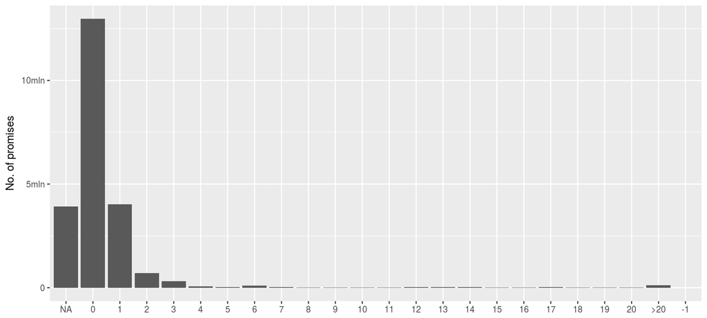

**n** - distance from the function for which a promise was created and the function in which it was evaluated  
**NA** - promise was not executed, there is no distance measure (a virgin promise)  
**-1** - promise was executed but there is no path from the origin to the point of evaluation (an escaped promise)

## Functions and calls by type

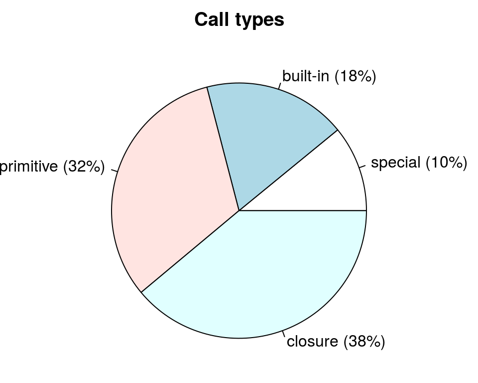

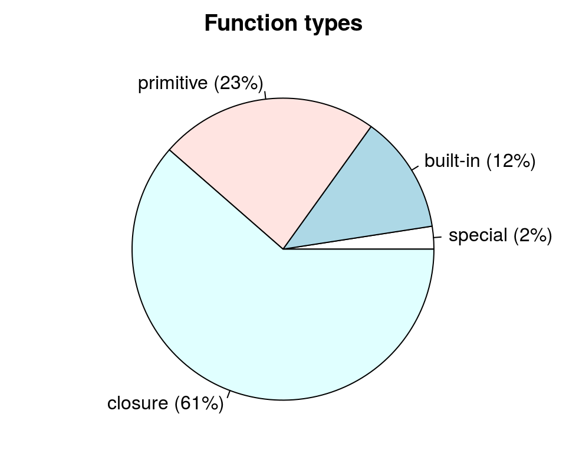

**functions** refers to function definitions  
**calls** refers to function executions/calls

## Byte-code compilation

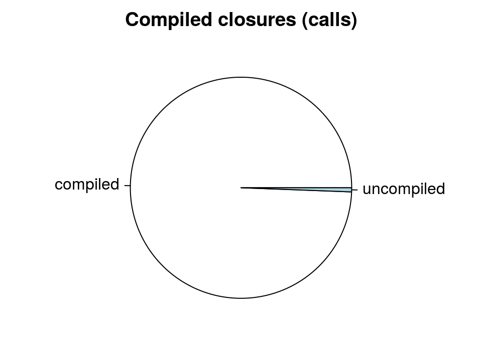

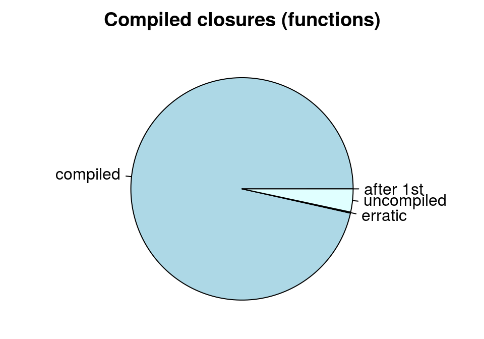

When calling a function it’s either byte-code **compiled** or **uncompiled**. When agregated across all calls to a function, a function can be:  
**compiled** - all calls to this function are compiled,  
**uncompiled** - none of the calls to this function are compiled,  
**after 1st** - a function can be compiled by the JIT, so it can be uncompiled initially and then compiled later on,  
**erratic** - a function is sometimes compiled and sometimes not; it can indicate that two separate functions are indistinguishable to the tracer (same definition, unknown location) and one of them is compiled while another is not.

## Interactions among promises

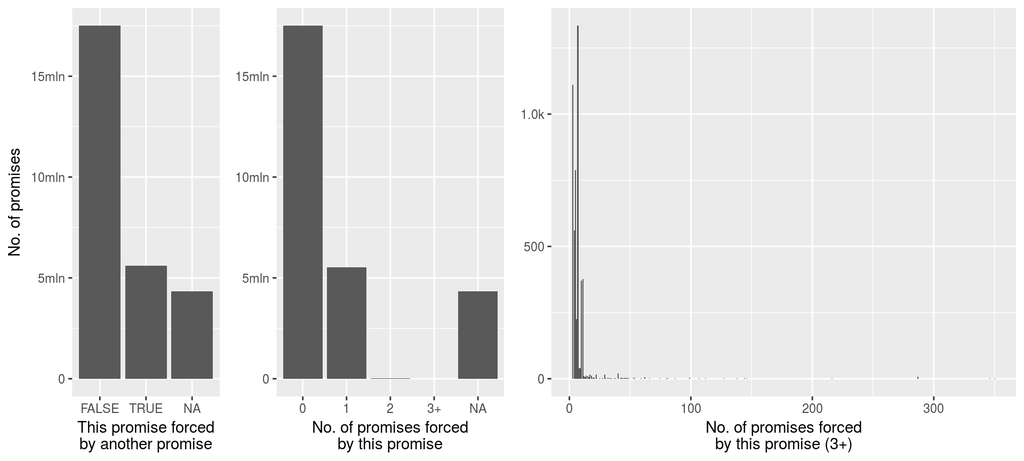

Promises forced by other promises:  
`TRUE` is when a promise was created within some promise x but was forced within a different promise y.  
`FALSE` is when a promise was forced within the same promise as it was created.  
`NA` means the promise was not forced.

## Strictness

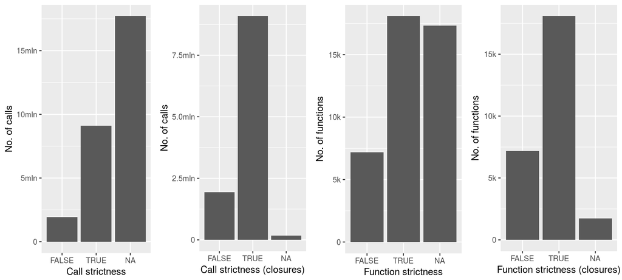

A call is **strict** if all of its arguments are **evaluated** and none of the arguments is **escaped**. (This means that a function may pass unevaluated promises to a child call and still be strict, but it cannot leak the promise).  
A function is **strict** if all of its calls are **strict**. Functions that don’t take promises are neither **strict** nor **non-strict** – these can be either arrity-0 closures or built-in (which accept values rather than promises).

## Call strictness ratios (dominant)

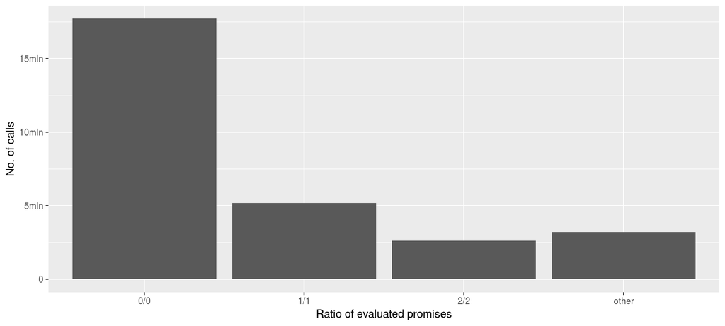

**Strictness ratio** of the form `n/m` means that a call evaluated `n` promises out of `m` promises that were created for it. `0/0` can mean either that a function had no arguments or that it was a built-in etc (had arguments, but they were passed without promises).

## Call strictness ratios (other top 20)

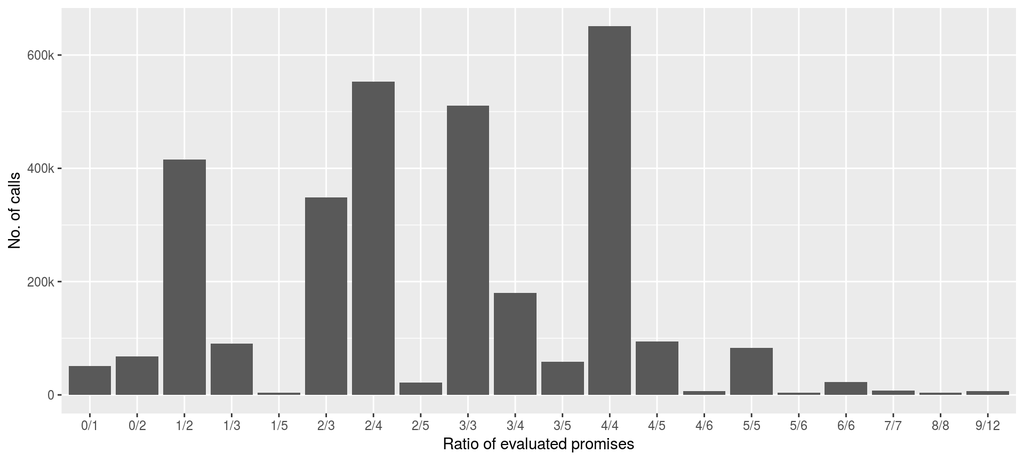

**Strictness ratio** of the form `n/m` means that a call evaluated `n` promises out of `m` promises that were created for it. `0/0` can mean either that a function had no arguments or that it was a built-in etc (had arguments, but they were passed without promises).

## Call strictness ratios (other - top 20)

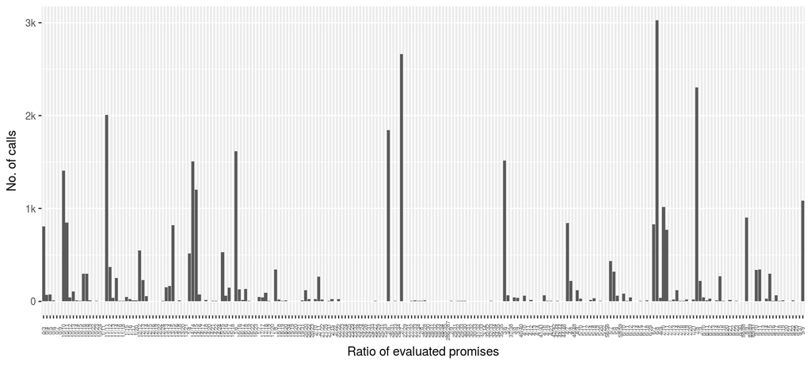

**Strictness ratio** of the form `n/m` means that a call evaluated `n` promises out of `m` promises that were created for it. `0/0` can mean either that a function had no arguments or that it was a built-in etc (had arguments, but they were passed without promises).

## Function strictness rate

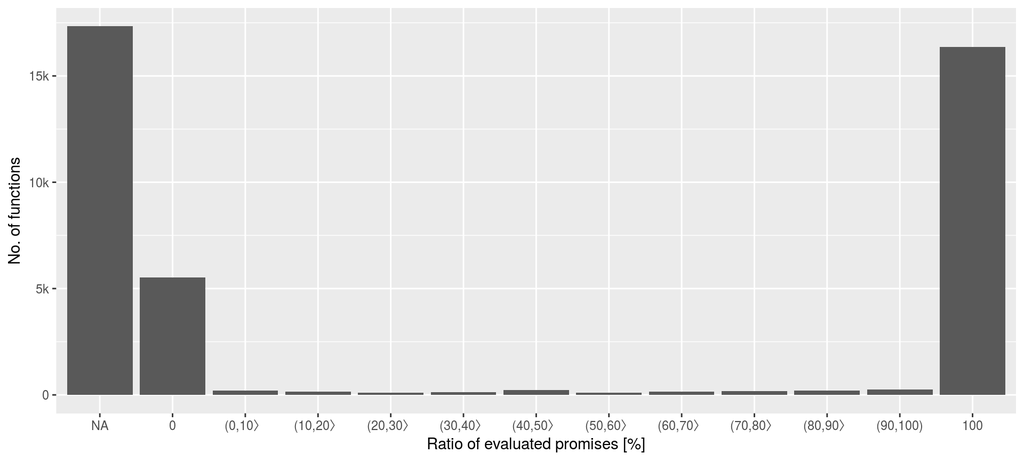

**Strictness rate** reflects what percentage of calls were strict.  
**NA** means the function had no argument.  
**(n,m〉** means the function had between n% and m% strict calls.

## Evaluation order

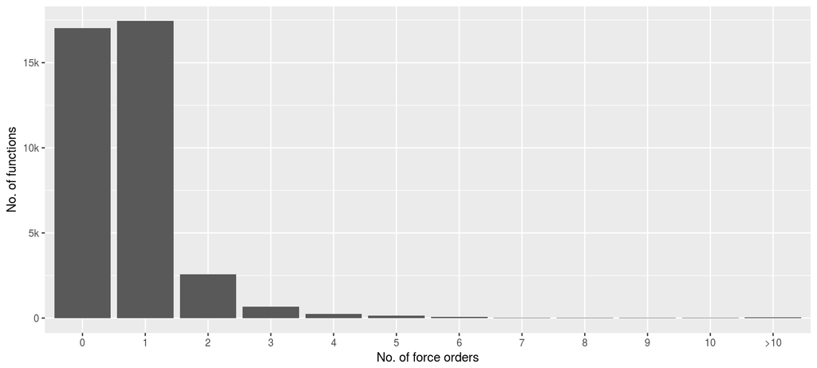

## Default and non-default promise arguments

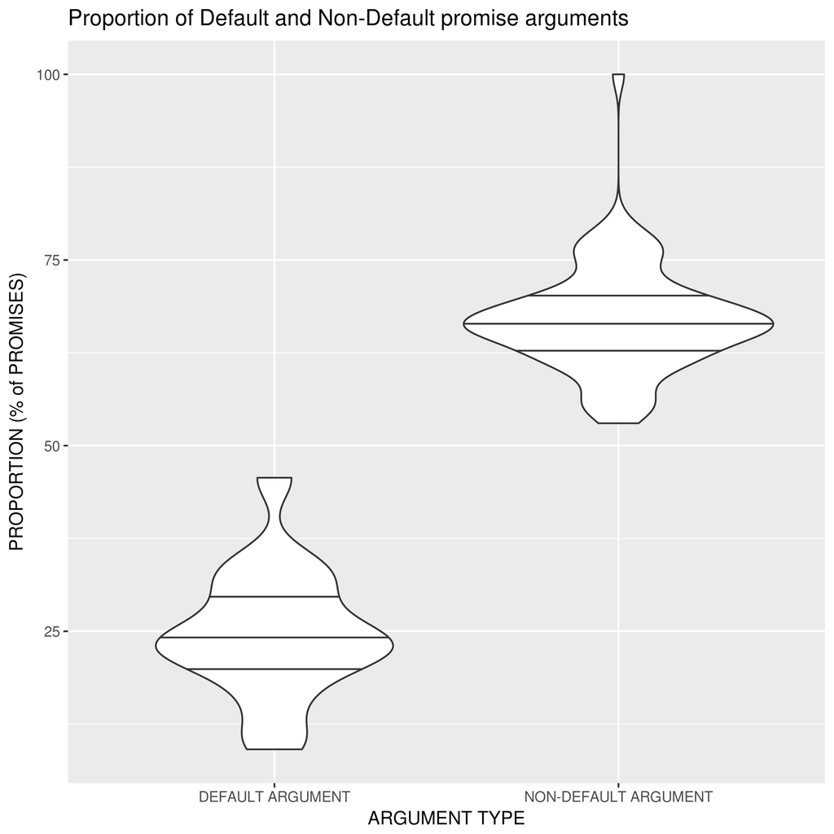

## Calls to specific functions

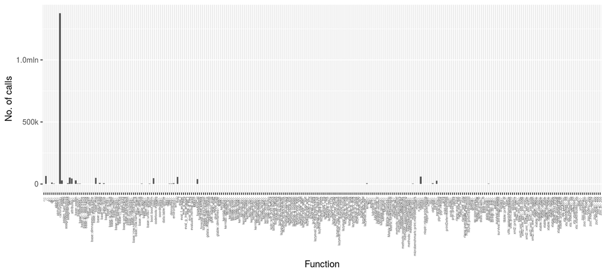